# Theme Park Wait Times: Patterns, Predictors, and Insights

- Show All Code
- Hide All Code
- View Source

Author

Evan Morrison

Published

May 8, 2026

# 1 Introduction

Theme parks are a massive industry, and one of the biggest factors shaping the guest experience is ride wait times. Long waits can make or break a park visit, and parks themselves invest heavily in systems like virtual queues and dynamic pricing to manage crowds. Understanding what drives wait times is both a practical question for park visitors and a relevant data problem for operations and business analytics.

This project sits at the intersection of something fun and relatable with real analytical value — the kind of question a theme park, tourism company, or operations team might actually want answered.

**Data Sources:**

- [Queue-Times.com](https://queue-times.com/) — Free API providing live wait time data for 80+ theme parks, collected every 30 minutes via an automated script over a multi-day period.
- [Open-Meteo](https://open-meteo.com/) — Free weather API providing hourly temperature and precipitation data for Orlando, FL.

*Powered by [Queue-Times.com](https://queue-times.com/)*

```r
# Load required packages
library(tidyverse)
library(jsonlite)
library(lubridate)
library(scales)
library(knitr)
library(broom)
library(gridExtra)
```

# 2 Data Collection

## 2.1 How the Data Was Collected

Wait time data was collected using an automated R script (`save_snapshot.R`) that runs every 30 minutes via a scheduled task. Each run queries the Queue-Times.com API for four Orlando-area parks and appends the results to a CSV file. The parks tracked are:

| Park | Queue-Times ID | Operator |
| --- | --- | --- |
| Magic Kingdom | 6 | Disney |
| Universal Studios Orlando | 65 | Universal |
| Islands of Adventure | 64 | Universal |
| Epic Universe | 334 | Universal |

The collection script ran continuously from the start of the data collection period through the analysis date, producing a dataset with thousands of observations across different hours, days, and parks.

## 2.2 Loading the Collected Data

```r
# ---- Load the collected CSV ----
csv_path <- "data/wait_times_log.csv"

if (!file.exists(csv_path)) {
  stop(
    "Data file not found at '", csv_path, "'.\n",
    "Run save_snapshot.R first to collect data. See the appendix for setup instructions."
  )
}

raw_data <- read_csv(csv_path, show_col_types = FALSE)

cat("Total rows loaded:", format(nrow(raw_data), big.mark = ","), "\n")
```

```
Total rows loaded: 39,215
```

```r
cat("Parks:", paste(unique(raw_data$park_name), collapse = ", "), "\n")
```

[output not shown]

```r
cat("Date range:",
    as.character(min(raw_data$snapshot_time, na.rm = TRUE)), "to",
    as.character(max(raw_data$snapshot_time, na.rm = TRUE)), "\n")
```

[output not shown]

## 2.3 Cleaning and Feature Engineering

```r
# ---- Clean and add time-based features ----
wait_data <- raw_data |>
  filter(is_open == TRUE, wait_time > 0) |>
  # OUTLIER REMOVAL: Filter out unrealistic wait times.
 # Values like 1000 minutes (~16.7 hours) are almost certainly API error codes
  # or placeholder values. A 3-hour (180 min) cap is a reasonable upper bound
  # for even the most popular rides during peak season.
  filter(wait_time <= 180) |>
  mutate(
    # Parse timestamps
    timestamp_utc = ymd_hms(last_updated),
    snapshot_dt = ymd_hms(snapshot_time),
    # Convert to Eastern Time (all four parks are in Orlando)
    timestamp_local = with_tz(timestamp_utc, tzone = "America/New_York"),
    # Time features
    hour = hour(timestamp_local),
    day_of_week = wday(timestamp_local, label = TRUE, abbr = FALSE),
    date = as.Date(timestamp_local),
    # Time of day categories
    time_of_day = case_when(
      hour >= 6 & hour < 12  ~ "Morning",
      hour >= 12 & hour < 17 ~ "Afternoon",
      hour >= 17 & hour < 21 ~ "Evening",
      TRUE                   ~ "Night"
    ) |> factor(levels = c("Morning", "Afternoon", "Evening", "Night")),
    # Weekend flag
    is_weekend = day_of_week %in% c("Saturday", "Sunday"),
    # Park operator
    operator = ifelse(park_name == "Magic Kingdom", "Disney", "Universal")
  )

n_removed <- nrow(raw_data |> filter(is_open == TRUE, wait_time > 180))
cat("Observations removed as outliers (wait > 180 min):", n_removed, "\n")
```

```
Observations removed as outliers (wait > 180 min): 6
```

```r
cat("Clean observations:", format(nrow(wait_data), big.mark = ","), "\n")
```

```
Clean observations: 15,488
```

```r
cat("Unique rides:", n_distinct(wait_data$ride_name), "\n")
```

```
Unique rides: 79
```

```r
cat("Unique days:", n_distinct(wait_data$date), "\n")
```

```
Unique days: 8
```

```r
cat("Unique hours covered:", n_distinct(wait_data$hour), "\n")
```

```
Unique hours covered: 19
```

```r
wait_data |>
  select(park_name, ride_name, wait_time, date, hour, time_of_day, is_weekend) |>
  head(15) |>
  kable(caption = "Preview of the cleaned dataset")
```

Preview of the cleaned dataset

| park_name | ride_name | wait_time | date | hour | time_of_day | is_weekend |
| --- | --- | --- | --- | --- | --- | --- |
| Magic Kingdom | Jungle Cruise | 45 | 2026-04-29 | 18 | Evening | FALSE |
| Magic Kingdom | Pirates of the Caribbean | 15 | 2026-04-29 | 18 | Evening | FALSE |
| Magic Kingdom | The Magic Carpets of Aladdin | 10 | 2026-04-29 | 18 | Evening | FALSE |
| Magic Kingdom | Walt Disney’s Enchanted Tiki Room | 10 | 2026-04-29 | 18 | Evening | FALSE |
| Magic Kingdom | “it’s a small world” | 5 | 2026-04-29 | 18 | Evening | FALSE |
| Magic Kingdom | Dumbo the Flying Elephant | 5 | 2026-04-29 | 18 | Evening | FALSE |
| Magic Kingdom | Enchanted Tales with Belle | 15 | 2026-04-29 | 18 | Evening | FALSE |
| Magic Kingdom | Mad Tea Party | 5 | 2026-04-29 | 18 | Evening | FALSE |
| Magic Kingdom | Meet Ariel at Her Grotto | 20 | 2026-04-29 | 18 | Evening | FALSE |
| Magic Kingdom | Meet Cinderella and a Visiting Princess at Princess Fairytale Hall | 35 | 2026-04-29 | 18 | Evening | FALSE |
| Magic Kingdom | Meet Princess Tiana and a Visiting Princess at Princess Fairytale Hall | 15 | 2026-04-29 | 18 | Evening | FALSE |
| Magic Kingdom | Mickey’s PhilharMagic | 10 | 2026-04-29 | 18 | Evening | FALSE |
| Magic Kingdom | Peter Pan’s Flight | 30 | 2026-04-29 | 18 | Evening | FALSE |
| Magic Kingdom | Prince Charming Regal Carrousel | 5 | 2026-04-29 | 18 | Evening | FALSE |
| Magic Kingdom | Seven Dwarfs Mine Train | 45 | 2026-04-29 | 18 | Evening | FALSE |

## 2.4 Adding Weather Data

We pull hourly temperature and precipitation data from the free [Open-Meteo API](https://open-meteo.com/) for Orlando, FL and merge it with the wait time data by date and hour.

```r
# ---- Fetch weather from Open-Meteo for the date range of our data ----
date_range <- range(wait_data$date)

cat("Fetching weather for date range:", as.character(date_range[1]),
    "to", as.character(date_range[2]), "\n")
```

```
Fetching weather for date range: 2026-04-29 to 2026-05-06
```

```r
# Use the archive API for past dates, forecast API for recent/future dates.
# The archive API covers dates up to ~5 days ago; the forecast API covers
# the last few days plus ~16 days ahead. We try archive first, then forecast.
weather <- tryCatch({

  # Try the archive API first (works for historical dates)
  archive_url <- paste0(
    "https://archive-api.open-meteo.com/v1/archive?",
    "latitude=28.4177&longitude=-81.5812",
    "&hourly=temperature_2m,precipitation,weather_code",
    "&temperature_unit=fahrenheit",
    "&timezone=America/New_York",
    "&start_date=", date_range[1],
    "&end_date=", date_range[2]
  )

  weather_raw <- tryCatch(fromJSON(archive_url), error = function(e) NULL)

  # If archive failed or returned an error, try forecast API
  if (is.null(weather_raw) || !is.null(weather_raw$error)) {
    cat("Archive API unavailable, trying forecast API...\n")
    forecast_url <- paste0(
      "https://api.open-meteo.com/v1/forecast?",
      "latitude=28.4177&longitude=-81.5812",
      "&hourly=temperature_2m,precipitation,weather_code",
      "&temperature_unit=fahrenheit",
      "&timezone=America/New_York",
      "&past_days=14",
      "&forecast_days=3"
    )
    weather_raw <- fromJSON(forecast_url)
  }

  tibble(
    datetime     = ymd_hm(weather_raw$hourly$time),
    temp_f       = weather_raw$hourly$temperature_2m,
    precip_mm    = weather_raw$hourly$precipitation,
    weather_code = weather_raw$hourly$weather_code
  ) |>
    mutate(
      date = as.Date(datetime),
      hour = hour(datetime),
      is_rainy = precip_mm > 0.5,
      temp_category = case_when(
        temp_f < 65  ~ "Cool (<65 F)",
        temp_f < 80  ~ "Mild (65-80 F)",
        temp_f >= 80 ~ "Hot (80 F+)"
      ) |> factor(levels = c("Cool (<65 F)", "Mild (65-80 F)", "Hot (80 F+)"))
    )
}, error = function(e) {
  cat("Could not fetch weather data:", conditionMessage(e), "\n")
  cat("Proceeding without weather variables.\n")
  NULL
})

# ---- Merge weather with wait data ----
if (!is.null(weather)) {
  wait_data <- wait_data |>
    left_join(weather |> select(date, hour, temp_f, precip_mm, is_rainy, temp_category),
              by = c("date", "hour"))
  cat("Weather data merged successfully.\n")
  cat("Temperature range:", round(min(wait_data$temp_f, na.rm = TRUE), 1),
      "to", round(max(wait_data$temp_f, na.rm = TRUE), 1), "F\n")
  has_weather <- TRUE
} else {
  has_weather <- FALSE
}
```

```
Weather data merged successfully.
Temperature range: 63.4 to 88.4 F
```

# 3 Exploratory Data Analysis

## 3.1 Summary Statistics by Park

```r
wait_data |>
  group_by(park_name) |>
  summarize(
    n = format(n(), big.mark = ","),
    rides = n_distinct(ride_name),
    mean_wait = round(mean(wait_time), 1),
    median_wait = median(wait_time),
    sd_wait = round(sd(wait_time), 1),
    max_wait = max(wait_time),
    .groups = "drop"
  ) |>
  kable(caption = "Summary statistics by park (minutes)",
        col.names = c("Park", "Observations", "Rides", "Mean", "Median", "SD", "Max"))
```

Summary statistics by park (minutes)

| Park | Observations | Rides | Mean | Median | SD | Max |
| --- | --- | --- | --- | --- | --- | --- |
| Epic Universe | 2,365 | 13 | 41.2 | 35 | 32.2 | 180 |
| Islands of Adventure | 3,051 | 17 | 23.9 | 15 | 26.2 | 180 |
| Magic Kingdom | 7,197 | 35 | 23.8 | 15 | 19.3 | 145 |
| Universal Studios Orlando | 2,875 | 14 | 17.2 | 15 | 14.8 | 120 |

## 3.2 Distribution of Wait Times

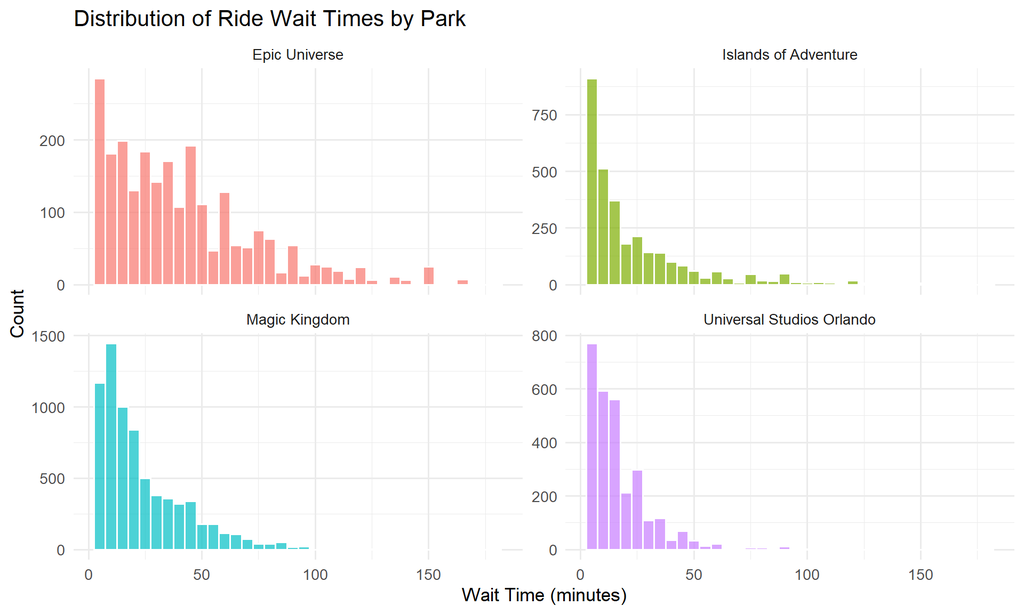

Figure 1: Distribution of ride wait times across all parks

```r
ggplot(wait_data, aes(x = wait_time, fill = park_name)) +
  geom_histogram(binwidth = 5, color = "white", alpha = 0.7) +
  facet_wrap(~park_name, scales = "free_y") +
  labs(
    title = "Distribution of Ride Wait Times by Park",
    x = "Wait Time (minutes)",
    y = "Count"
  ) +
  theme_minimal(base_size = 13) +
  theme(legend.position = "none")
```

## 3.3 Wait Times by Time of Day

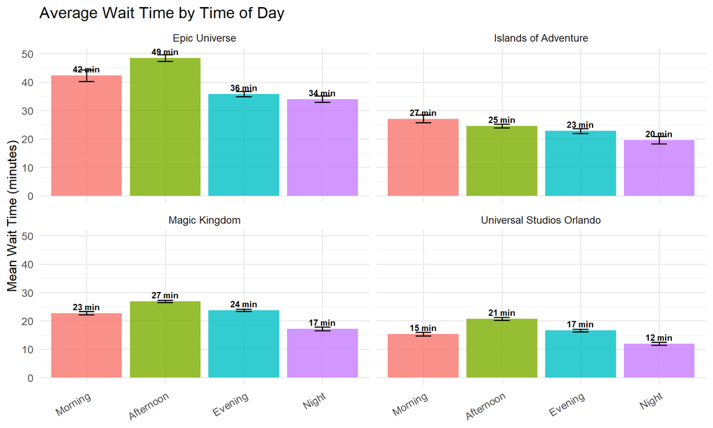

Figure 2: Average wait times by time of day, faceted by park

```r
wait_data |>
  group_by(park_name, time_of_day) |>
  summarize(
    mean_wait = mean(wait_time),
    se = ifelse(n() > 1, sd(wait_time) / sqrt(n()), 0),
    .groups = "drop"
  ) |>
  ggplot(aes(x = time_of_day, y = mean_wait, fill = time_of_day)) +
  geom_col(alpha = 0.8, show.legend = FALSE) +
  geom_errorbar(aes(ymin = mean_wait - se, ymax = mean_wait + se), width = 0.2) +
  geom_text(aes(label = paste0(round(mean_wait, 0), " min")),
            vjust = -0.5, size = 3, fontface = "bold") +
  facet_wrap(~park_name) +
  labs(
    title = "Average Wait Time by Time of Day",
    x = NULL, y = "Mean Wait Time (minutes)"
  ) +
  theme_minimal(base_size = 13) +
  theme(axis.text.x = element_text(angle = 30, hjust = 1))
```

## 3.4 Wait Times by Day of Week

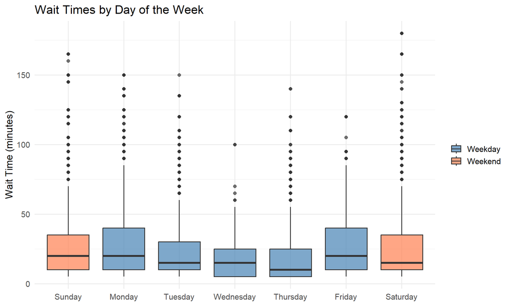

Figure 3: Wait times by day of the week

```r
wait_data |>
  ggplot(aes(x = day_of_week, y = wait_time, fill = is_weekend)) +
  geom_boxplot(alpha = 0.7) +
  scale_fill_manual(values = c("FALSE" = "steelblue", "TRUE" = "coral"),
                    labels = c("Weekday", "Weekend")) +
  labs(
    title = "Wait Times by Day of the Week",
    x = NULL,
    y = "Wait Time (minutes)",
    fill = NULL
  ) +
  theme_minimal(base_size = 14)
```

## 3.5 Weather Effects on Wait Times

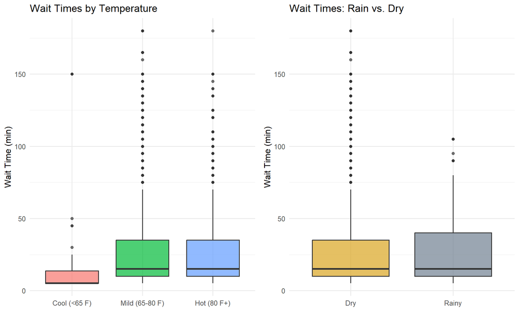

Figure 4: How temperature and rain affect wait times

```r
if (has_weather) {
  p1 <- wait_data |>
    filter(!is.na(temp_category)) |>
    ggplot(aes(x = temp_category, y = wait_time, fill = temp_category)) +
    geom_boxplot(alpha = 0.7, show.legend = FALSE) +
    labs(title = "Wait Times by Temperature", x = NULL, y = "Wait Time (min)") +
    theme_minimal(base_size = 12)

  p2 <- wait_data |>
    filter(!is.na(is_rainy)) |>
    mutate(rain_label = ifelse(is_rainy, "Rainy", "Dry")) |>
    ggplot(aes(x = rain_label, y = wait_time, fill = rain_label)) +
    geom_boxplot(alpha = 0.7, show.legend = FALSE) +
    scale_fill_manual(values = c("Dry" = "goldenrod", "Rainy" = "slategray")) +
    labs(title = "Wait Times: Rain vs. Dry", x = NULL, y = "Wait Time (min)") +
    theme_minimal(base_size = 12)

  grid.arrange(p1, p2, ncol = 2)
} else {
  cat("Weather data not available.\n")
}
```

# 4 Statistical Tests

## 4.1 Research Question 1a: Do Wait Times Differ by Time of Day?

```r
# ---- One-Way ANOVA: Wait Time ~ Time of Day ----
if (n_distinct(wait_data$time_of_day) > 1) {
  aov_time <- aov(wait_time ~ time_of_day, data = wait_data)
  print(summary(aov_time))
} else {
  cat("Only one time-of-day category in current data — need more snapshots.\n")
}
```

```
               Df  Sum Sq Mean Sq F value Pr(>F)
time_of_day     3  167593   55864   101.8 <2e-16 ***
Residuals   15484 8499003     549
---
Signif. codes:  0 '***' 0.001 '**' 0.01 '*' 0.05 '.' 0.1 ' ' 1
```

```r
if (n_distinct(wait_data$time_of_day) > 1) {
  tukey_result <- TukeyHSD(aov_time)
  tukey_df <- as.data.frame(tukey_result$time_of_day) |>
    rownames_to_column("comparison") |>
    mutate(significant = ifelse(`p adj` < 0.05, "Yes", "No"))

  tukey_df |>
    mutate(across(where(is.numeric), ~round(., 3))) |>
    kable(caption = "Tukey's HSD pairwise comparisons for time of day")
}
```

Tukey’s HSD pairwise comparisons for time of day

| comparison | diff | lwr | upr | p adj | significant |
| --- | --- | --- | --- | --- | --- |
| Afternoon-Morning | 2.982 | 1.467 | 4.497 | 0.000 | Yes |
| Evening-Morning | -1.218 | -2.716 | 0.281 | 0.157 | No |
| Night-Morning | -7.752 | -9.645 | -5.860 | 0.000 | Yes |
| Evening-Afternoon | -4.199 | -5.327 | -3.071 | 0.000 | Yes |
| Night-Afternoon | -10.734 | -12.349 | -9.119 | 0.000 | Yes |
| Night-Evening | -6.535 | -8.134 | -4.935 | 0.000 | Yes |

## 4.2 Research Question 1b: Do Wait Times Differ by Day of the Week?

```r
if (n_distinct(wait_data$day_of_week) > 1) {
  aov_day <- aov(wait_time ~ day_of_week, data = wait_data)
  print(summary(aov_day))
} else {
  cat("Only one day of week in current data — need more days.\n")
}
```

```
               Df  Sum Sq Mean Sq F value Pr(>F)
day_of_week     6  101591   16932    30.6 <2e-16 ***
Residuals   15481 8565004     553
---
Signif. codes:  0 '***' 0.001 '**' 0.01 '*' 0.05 '.' 0.1 ' ' 1
```

## 4.3 Weekend vs. Weekday Comparison

```r
if (n_distinct(wait_data$is_weekend) > 1) {
  t_result <- t.test(wait_time ~ is_weekend, data = wait_data)
  print(t_result)

  wait_data |>
    group_by(is_weekend) |>
    summarize(n = n(), mean_wait = round(mean(wait_time), 1),
              sd_wait = round(sd(wait_time), 1), .groups = "drop") |>
    mutate(day_type = ifelse(is_weekend, "Weekend", "Weekday")) |>
    select(day_type, n, mean_wait, sd_wait) |>
    kable(caption = "Wait times: weekday vs. weekend",
          col.names = c("Day Type", "N", "Mean Wait", "SD"))
} else {
  cat("Only one type (weekday or weekend) in the data.\n")
}
```

```
    Welch Two Sample t-test

data:  wait_time by is_weekend
t = -1.1301, df = 15347, p-value = 0.2585
alternative hypothesis: true difference in means between group FALSE and group TRUE is not equal to 0
95 percent confidence interval:
 -1.1764549  0.3159937
sample estimates:
mean in group FALSE  mean in group TRUE
           25.03947            25.46970
```

Wait times: weekday vs. weekend

| Day Type | N | Mean Wait | SD |
| --- | --- | --- | --- |
| Weekday | 7930 | 25.0 | 23.1 |
| Weekend | 7558 | 25.5 | 24.2 |

## 4.4 Research Question 3: Disney vs. Universal

```
    Welch Two Sample t-test

data:  wait_time by operator
t = -7.2926, df = 14976, p-value = 3.192e-13
alternative hypothesis: true difference in means between group Disney and group Universal is not equal to 0
95 percent confidence interval:
 -3.442122 -1.983745
sample estimates:
   mean in group Disney mean in group Universal
               23.79714                26.51007
```

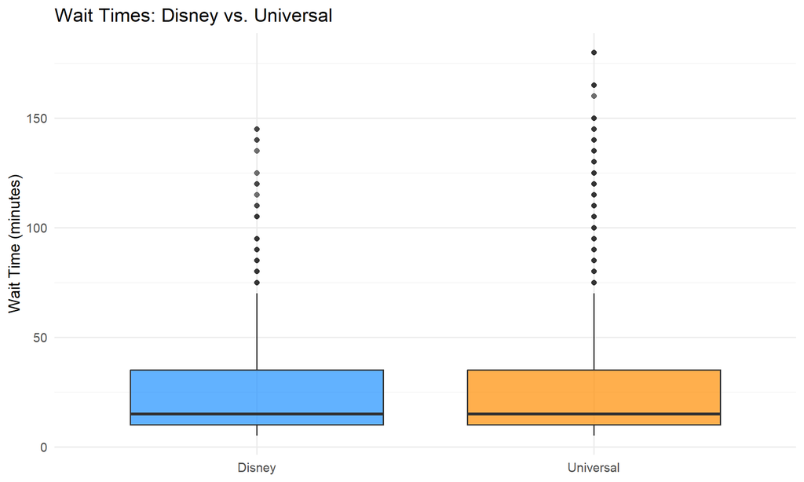

Wait time comparison: Disney vs. Universal parks

```r
if (n_distinct(wait_data$operator) > 1) {
  t_parks <- t.test(wait_time ~ operator, data = wait_data)
  print(t_parks)

  wait_data |>
    ggplot(aes(x = operator, y = wait_time, fill = operator)) +
    geom_boxplot(alpha = 0.7) +
    scale_fill_manual(values = c("Disney" = "dodgerblue", "Universal" = "darkorange")) +
    labs(
      title = "Wait Times: Disney vs. Universal",
      x = NULL, y = "Wait Time (minutes)", fill = NULL
    ) +
    theme_minimal(base_size = 14) +
    theme(legend.position = "none")
} else {
  cat("Only one operator in the data.\n")
}
```

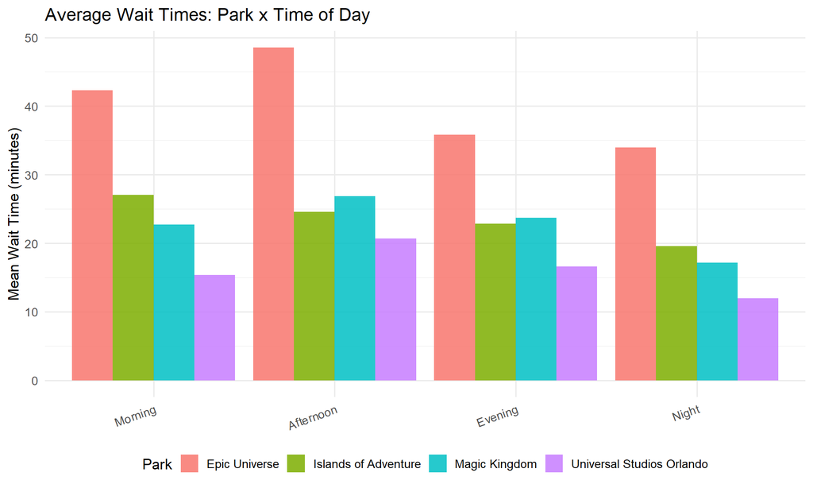

Average wait times by park and time of day

```r
if (n_distinct(wait_data$park_name) > 1 & n_distinct(wait_data$time_of_day) > 1) {
  wait_data |>
    group_by(park_name, time_of_day) |>
    summarize(mean_wait = mean(wait_time), .groups = "drop") |>
    ggplot(aes(x = time_of_day, y = mean_wait, fill = park_name)) +
    geom_col(position = "dodge", alpha = 0.85) +
    labs(
      title = "Average Wait Times: Park x Time of Day",
      x = NULL, y = "Mean Wait Time (minutes)", fill = "Park"
    ) +
    theme_minimal(base_size = 13) +
    theme(legend.position = "bottom",
          axis.text.x = element_text(angle = 20, hjust = 1))
}
```

### 4.4.1 ANOVA: Wait Time by Park

```r
if (n_distinct(wait_data$park_name) > 1) {
  aov_park <- aov(wait_time ~ park_name, data = wait_data)
  print(summary(aov_park))

  tukey_park <- TukeyHSD(aov_park)
  as.data.frame(tukey_park$park_name) |>
    rownames_to_column("comparison") |>
    mutate(
      significant = ifelse(`p adj` < 0.05, "Yes", "No"),
      across(where(is.numeric), ~round(., 3))
    ) |>
    kable(caption = "Tukey's HSD pairwise comparisons between parks")
}
```

```
               Df  Sum Sq Mean Sq F value Pr(>F)
park_name       3  805867  268622   529.1 <2e-16 ***
Residuals   15484 7860729     508
---
Signif. codes:  0 '***' 0.001 '**' 0.01 '*' 0.05 '.' 0.1 ' ' 1
```

Tukey’s HSD pairwise comparisons between parks

| comparison | diff | lwr | upr | p adj | significant |
| --- | --- | --- | --- | --- | --- |
| Islands of Adventure-Epic Universe | -17.266 | -18.852 | -15.680 | 0.000 | Yes |
| Magic Kingdom-Epic Universe | -17.374 | -18.746 | -16.002 | 0.000 | Yes |
| Universal Studios Orlando-Epic Universe | -23.957 | -25.564 | -22.350 | 0.000 | Yes |
| Magic Kingdom-Islands of Adventure | -0.108 | -1.359 | 1.142 | 0.996 | No |
| Universal Studios Orlando-Islands of Adventure | -6.691 | -8.196 | -5.187 | 0.000 | Yes |
| Universal Studios Orlando-Magic Kingdom | -6.583 | -7.860 | -5.306 | 0.000 | Yes |

# 5 Regression Analysis

## 5.1 Research Question 2: Predicting Wait Times

We build a multiple linear regression model with all available predictors. The model dynamically includes only variables that have sufficient variation (2+ levels for categorical, nonzero variance for numeric).

```r
# ---- Dynamically select usable predictors ----
candidate_predictors <- c("park_name", "time_of_day",
                          "is_weekend", "day_of_week")

# Add weather predictors if available
if (has_weather) {
  candidate_predictors <- c(candidate_predictors, "temp_f", "is_rainy")
}

usable_predictors <- candidate_predictors[
  sapply(candidate_predictors, function(v) {
    if (is.numeric(wait_data[[v]])) {
      sd(wait_data[[v]], na.rm = TRUE) > 0
    } else {
      n_distinct(wait_data[[v]], na.rm = TRUE) >= 2
    }
  })
]

cat("Predictors included:", paste(usable_predictors, collapse = ", "), "\n\n")
```

```
Predictors included: park_name, time_of_day, is_weekend, day_of_week, temp_f, is_rainy
```

```r
if (length(usable_predictors) == 0) {
  cat("No predictors with enough variation — collect more data.\n")
  model <- NULL
} else {
  model_formula <- as.formula(
    paste("wait_time ~", paste(usable_predictors, collapse = " + "))
  )
  cat("Formula:", deparse(model_formula), "\n\n")

  model <- lm(model_formula, data = wait_data)
  summary(model)
}
```

```
Formula: wait_time ~ park_name + time_of_day + is_weekend + day_of_week +      temp_f + is_rainy
```

```
Call:
lm(formula = model_formula, data = wait_data)

Residuals:
    Min      1Q  Median      3Q     Max
-41.917 -13.570  -6.314   7.930 155.817

Coefficients: (1 not defined because of singularities)
                                    Estimate Std. Error t value Pr(>|t|)
(Intercept)                         36.23096    8.04486   4.504 6.73e-06 ***
park_nameIslands of Adventure      -17.19250    0.61048 -28.162  < 2e-16 ***
park_nameMagic Kingdom             -16.73737    0.52751 -31.729  < 2e-16 ***
park_nameUniversal Studios Orlando -23.39277    0.61975 -37.746  < 2e-16 ***
time_of_dayAfternoon                 2.67373    0.63591   4.205 2.63e-05 ***
time_of_dayEvening                  -2.24017    0.63490  -3.528 0.000419 ***
time_of_dayNight                    -6.29675    0.75107  -8.384  < 2e-16 ***
is_weekendTRUE                     -21.08663   19.59199  -1.076 0.281815
day_of_week.L                        1.12267    0.55691   2.016 0.043827 *
day_of_week.Q                       28.72300   20.59395   1.395 0.163117
day_of_week.C                       -0.19222    0.51349  -0.374 0.708155
day_of_week^4                        3.04684   10.25457   0.297 0.766378
day_of_week^5                       -1.84210    0.53072  -3.471 0.000520 ***
day_of_week^6                             NA         NA      NA       NA
temp_f                               0.13298    0.06154   2.161 0.030715 *
is_rainyTRUE                         1.28315    1.23550   1.039 0.299021
---
Signif. codes:  0 '***' 0.001 '**' 0.01 '*' 0.05 '.' 0.1 ' ' 1

Residual standard error: 22.19 on 15473 degrees of freedom
Multiple R-squared:  0.1206,    Adjusted R-squared:  0.1198
F-statistic: 151.6 on 14 and 15473 DF,  p-value: < 2.2e-16
```

### 5.1.1 Model Diagnostics

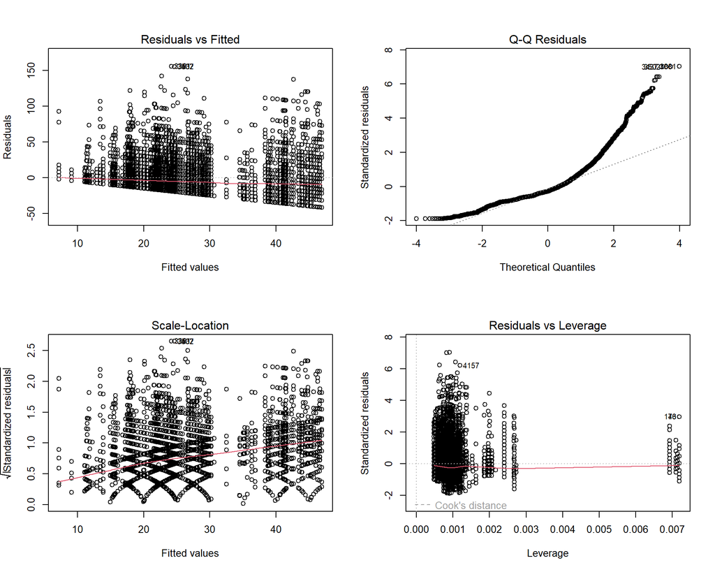

Figure 5: Regression diagnostic plots

```r
if (!is.null(model)) {
  par(mfrow = c(2, 2))
  plot(model)
  par(mfrow = c(1, 1))
}
```

### 5.1.2 Coefficient Table

```r
if (!is.null(model)) {
  tidy(model, conf.int = TRUE) |>
    mutate(across(where(is.numeric), ~round(., 3))) |>
    arrange(p.value) |>
    kable(caption = "Regression coefficients (sorted by significance)")
}
```

Regression coefficients (sorted by significance)

| term | estimate | std.error | statistic | p.value | conf.low | conf.high |
| --- | --- | --- | --- | --- | --- | --- |
| (Intercept) | 36.231 | 8.045 | 4.504 | 0.000 | 20.462 | 52.000 |
| park_nameIslands of Adventure | -17.193 | 0.610 | -28.162 | 0.000 | -18.389 | -15.996 |
| park_nameMagic Kingdom | -16.737 | 0.528 | -31.729 | 0.000 | -17.771 | -15.703 |
| park_nameUniversal Studios Orlando | -23.393 | 0.620 | -37.746 | 0.000 | -24.608 | -22.178 |
| time_of_dayAfternoon | 2.674 | 0.636 | 4.205 | 0.000 | 1.427 | 3.920 |
| time_of_dayEvening | -2.240 | 0.635 | -3.528 | 0.000 | -3.485 | -0.996 |
| time_of_dayNight | -6.297 | 0.751 | -8.384 | 0.000 | -7.769 | -4.825 |
| day_of_week^5 | -1.842 | 0.531 | -3.471 | 0.001 | -2.882 | -0.802 |
| temp_f | 0.133 | 0.062 | 2.161 | 0.031 | 0.012 | 0.254 |
| day_of_week.L | 1.123 | 0.557 | 2.016 | 0.044 | 0.031 | 2.214 |
| day_of_week.Q | 28.723 | 20.594 | 1.395 | 0.163 | -11.644 | 69.090 |
| is_weekendTRUE | -21.087 | 19.592 | -1.076 | 0.282 | -59.489 | 17.316 |
| is_rainyTRUE | 1.283 | 1.235 | 1.039 | 0.299 | -1.139 | 3.705 |
| day_of_week.C | -0.192 | 0.513 | -0.374 | 0.708 | -1.199 | 0.814 |
| day_of_week^4 | 3.047 | 10.255 | 0.297 | 0.766 | -17.053 | 23.147 |
| day_of_week^6 | NA | NA | NA | NA | NA | NA |

### 5.1.3 Model Fit

```r
if (!is.null(model)) {
  glance_stats <- glance(model)
  cat("R-squared:", round(glance_stats$r.squared, 4), "\n")
  cat("Adjusted R-squared:", round(glance_stats$adj.r.squared, 4), "\n")
  cat("F-statistic:", round(glance_stats$statistic, 2),
      " (p =", format.pval(glance_stats$p.value, digits = 4), ")\n")
  cat("Residual Std Error:", round(glance_stats$sigma, 2), "minutes\n")
}
```

```
R-squared: 0.1206
Adjusted R-squared: 0.1198
F-statistic: 151.55  (p = < 2.2e-16 )
Residual Std Error: 22.19 minutes
```

### 5.1.4 Predicted vs. Actual

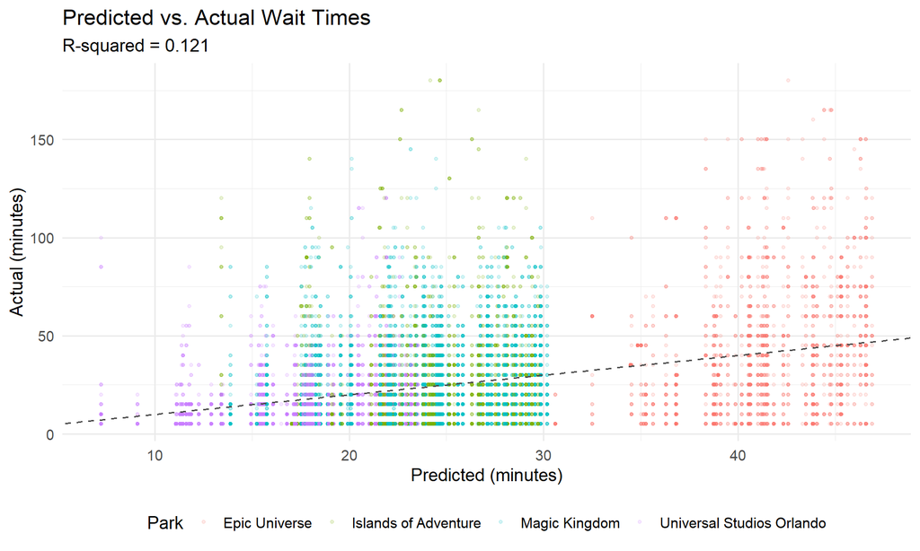

Figure 6: Predicted vs. actual wait times

```r
if (!is.null(model)) {
  wait_data <- wait_data |>
    mutate(predicted = predict(model, newdata = wait_data))

  ggplot(wait_data, aes(x = predicted, y = wait_time)) +
    geom_point(aes(color = park_name), alpha = 0.15, size = 1) +
    geom_abline(slope = 1, intercept = 0, linetype = "dashed", color = "gray30") +
    labs(
      title = "Predicted vs. Actual Wait Times",
      subtitle = paste("R-squared =", round(glance_stats$r.squared, 3)),
      x = "Predicted (minutes)", y = "Actual (minutes)", color = "Park"
    ) +
    theme_minimal(base_size = 14) +
    theme(legend.position = "bottom")
}
```

# 6 Novelty Decay Analysis

## 6.1 Research Question 4: Do New Rides Lose Their Edge?

Epic Universe opened on May 22, 2025, making it the newest major park in Orlando. Its rides — including Harry Potter and the Battle at the Ministry, Mario Kart: Bowser’s Challenge, and Mine-Cart Madness — launched with enormous hype. Meanwhile, Tron Lightcycle Run opened at Magic Kingdom on April 4, 2023, giving us a ride that is now three years old but was once the newest attraction in the park.

We can examine whether rides from newer parks/openings show declining wait times over the collection period, which would suggest a “novelty decay” effect.

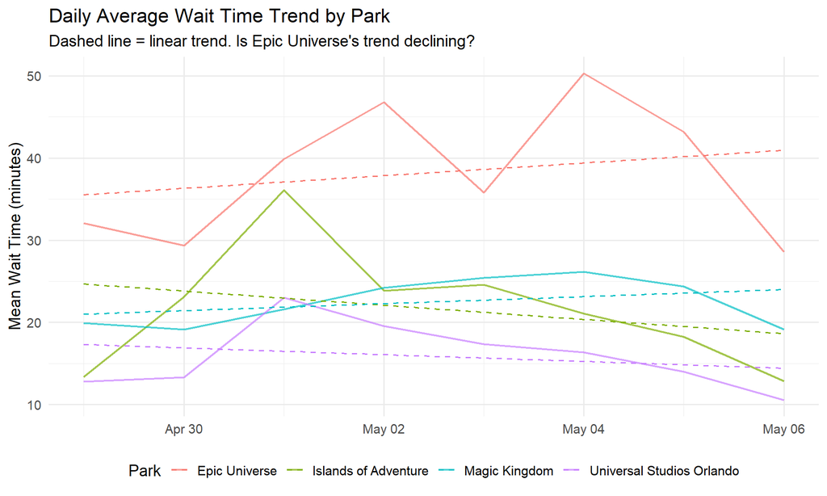

Figure 7: Daily average wait time trend for Epic Universe vs. established parks

```r
if (n_distinct(wait_data$park_name) > 1 & n_distinct(wait_data$date) > 1) {
  daily_park_avg <- wait_data |>
    group_by(date, park_name) |>
    summarize(mean_wait = mean(wait_time), .groups = "drop")

  ggplot(daily_park_avg, aes(x = date, y = mean_wait, color = park_name)) +
    geom_line(linewidth = 0.8, alpha = 0.7) +
    geom_smooth(method = "lm", se = FALSE, linetype = "dashed", linewidth = 0.6) +
    labs(
      title = "Daily Average Wait Time Trend by Park",
      subtitle = "Dashed line = linear trend. Is Epic Universe's trend declining?",
      x = NULL, y = "Mean Wait Time (minutes)", color = "Park"
    ) +
    theme_minimal(base_size = 14) +
    theme(legend.position = "bottom")
}
```

```r
# ---- Test for a time trend in each park ----
if (n_distinct(wait_data$date) >= 3) {
  wait_data |>
    mutate(day_num = as.numeric(date - min(date))) |>
    group_by(park_name) |>
    summarize(
      slope = round(coef(lm(wait_time ~ day_num))[2], 3),
      p_value = round(summary(lm(wait_time ~ day_num))$coefficients[2, 4], 4),
      interpretation = case_when(
        p_value >= 0.05 ~ "No significant trend",
        slope < 0 ~ "Wait times DECREASING over time",
        slope > 0 ~ "Wait times INCREASING over time"
      ),
      .groups = "drop"
    ) |>
    kable(caption = "Linear trend in wait times over the collection period",
          col.names = c("Park", "Slope (min/day)", "p-value", "Interpretation"))
}
```

Linear trend in wait times over the collection period

| Park | Slope (min/day) | p-value | Interpretation |
| --- | --- | --- | --- |
| Epic Universe | 0.880 | 0.0331 | Wait times INCREASING over time |
| Islands of Adventure | -1.735 | 0.0000 | Wait times DECREASING over time |
| Magic Kingdom | 0.478 | 0.0004 | Wait times INCREASING over time |
| Universal Studios Orlando | -0.894 | 0.0000 | Wait times DECREASING over time |

### 6.1.1 Headline Ride Trends

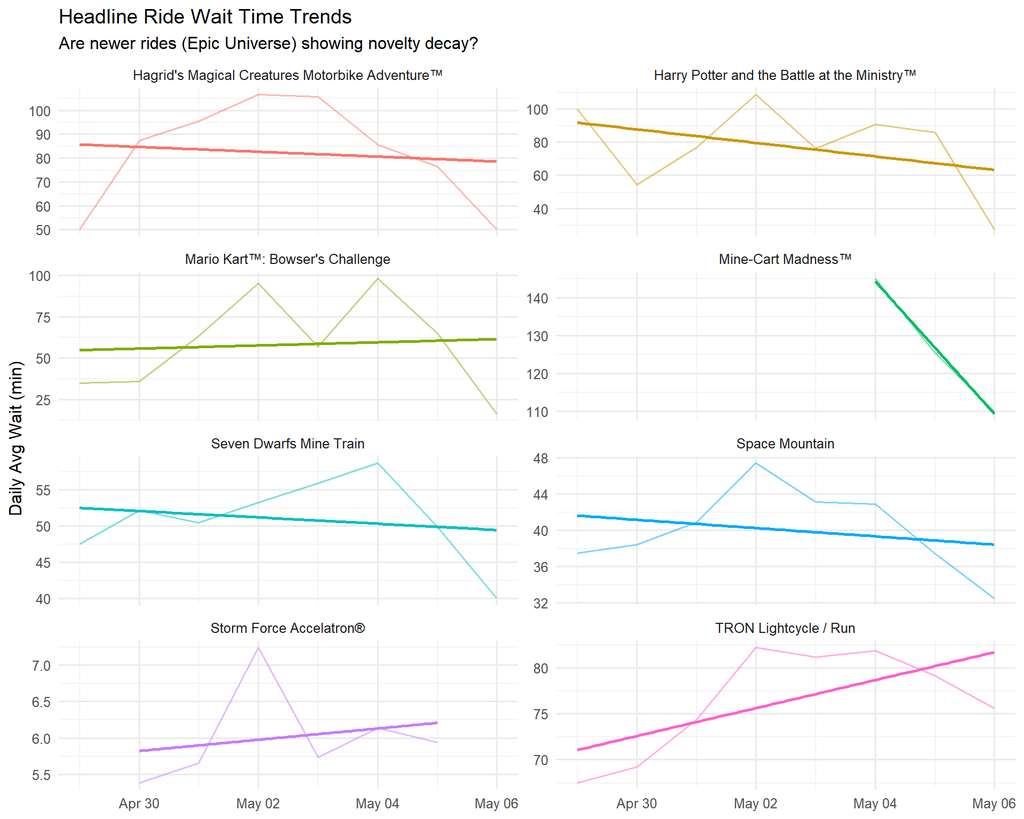

Figure 8: Wait time trends for specific headline rides

```r
# ---- Track specific high-profile rides ----
headline_data <- wait_data |>
  filter(str_detect(ride_name, regex(
    "tron|mario kart|mine.cart|battle.*ministry|hagrid|seven dwarfs|space mountain",
    ignore_case = TRUE
  )))

if (nrow(headline_data) > 10 & n_distinct(headline_data$date) > 1) {
  headline_data |>
    group_by(date, ride_name) |>
    summarize(mean_wait = mean(wait_time), .groups = "drop") |>
    ggplot(aes(x = date, y = mean_wait, color = ride_name)) +
    geom_line(alpha = 0.5) +
    geom_smooth(method = "lm", se = FALSE, linewidth = 1) +
    facet_wrap(~ride_name, scales = "free_y", ncol = 2) +
    labs(
      title = "Headline Ride Wait Time Trends",
      subtitle = "Are newer rides (Epic Universe) showing novelty decay?",
      x = NULL, y = "Daily Avg Wait (min)"
    ) +
    theme_minimal(base_size = 12) +
    theme(legend.position = "none")
} else {
  cat("Not enough data for headline ride trends yet.\n")
  cat("Rides found:", paste(unique(headline_data$ride_name), collapse = ", "), "\n")
}
```

# 7 Top Rides Leaderboard

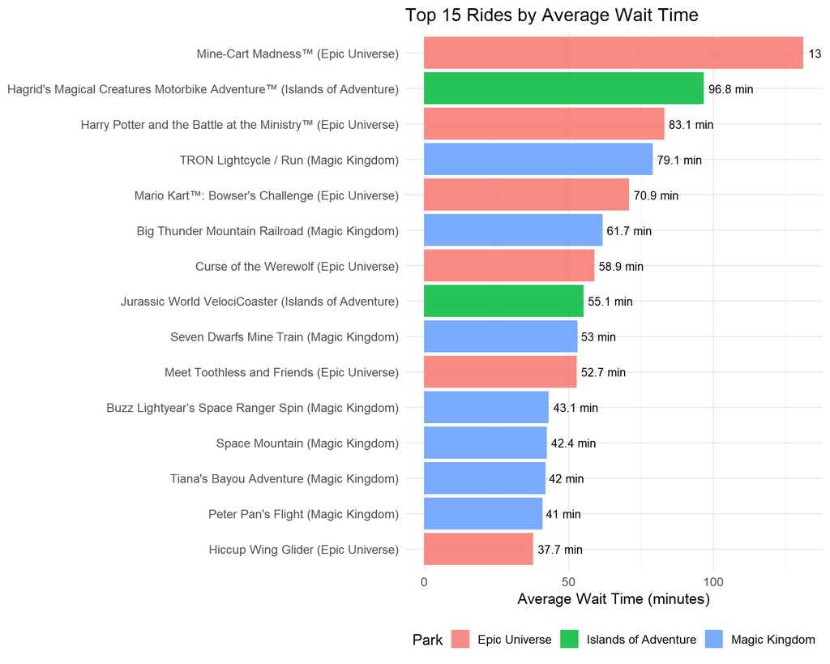

Figure 9: Top 15 rides by average wait time across the collection period

```r
wait_data |>
  group_by(park_name, ride_name) |>
  summarize(mean_wait = round(mean(wait_time), 1),
            max_wait = max(wait_time),
            n = n(), .groups = "drop") |>
  filter(n >= 5) |>
  slice_max(mean_wait, n = 15) |>
  mutate(ride_label = paste0(ride_name, " (", park_name, ")"),
         ride_label = fct_reorder(ride_label, mean_wait)) |>
  ggplot(aes(x = mean_wait, y = ride_label, fill = park_name)) +
  geom_col(alpha = 0.85) +
  geom_text(aes(label = paste0(mean_wait, " min")), hjust = -0.1, size = 3.5) +
  labs(
    title = "Top 15 Rides by Average Wait Time",
    x = "Average Wait Time (minutes)", y = NULL, fill = "Park"
  ) +
  theme_minimal(base_size = 13) +
  theme(legend.position = "bottom")
```

# 8 Appendix: Data Collection Setup

## 8.1 Collection Script

The `save_snapshot.R` script (included with this notebook) collects wait times from all four parks every time it runs. To automate it:

**Mac/Linux (cron):**

Open Terminal and run `crontab -e`, then add:

```
*/30 * * * * cd /path/to/your/project && /usr/local/bin/Rscript save_snapshot.R >> data/cron_log.txt 2>&1
```

**Windows (Task Scheduler):**

1. Open Task Scheduler and click “Create Basic Task”
2. Set trigger to Daily, then in Advanced settings check “Repeat task every 30 minutes”
3. Action → Start a Program:
   - Program: `C:\Program Files\R\R-4.x.x\bin\Rscript.exe`
   - Arguments: `save_snapshot.R`
   - Start in: `C:\Users\YourName\path\to\project`

## 8.2 Required Packages

```r
install.packages(c("tidyverse", "jsonlite", "lubridate",
                    "scales", "knitr", "broom", "gridExtra"))
```

# 9 Conclusion

This analysis demonstrates a complete, reproducible pipeline for collecting, exploring, and modeling theme park wait times using R, public APIs, and Quarto.

**Data Cleaning Note:** Observations with posted wait times exceeding 180 minutes (3 hours) were removed as likely data errors or API placeholder values. These extreme values (e.g., 1000 minutes) are unrealistic for theme park queues and would distort both visualizations and statistical models.

**Limitations:**

- Posted wait times may overestimate actual waits by 10–15% (parks pad estimates to manage guest expectations).
- The collection period covers approximately one week; a longer period spanning multiple seasons would strengthen the seasonal analysis.
- The regression model explains variation in wait times but does not capture ride-specific factors like virtual queue effects or Lightning Lane availability.

*Data powered by [Queue-Times.com](https://queue-times.com/). Weather data from [Open-Meteo](https://open-meteo.com/). Analysis conducted in R with Quarto.*